# Lesson 5A: Data Visualization with ggplot2

## `ggplot2` and the grammar of graphic

- `ggplot2` is an R package for data visualization which implements the **grammar of graphics** introduced by Leland Wilkinson.
- While base R graphics we have seen are generally fast, `ggplot2` is versatile and widely used for making elegant and beautiful graphics.
- `ggplot2` is good for visualizing the relationship between multiple variables.
- The **grammar of graphic** of Leland Wilkinson defines a statistical graph based on the following layers (components):

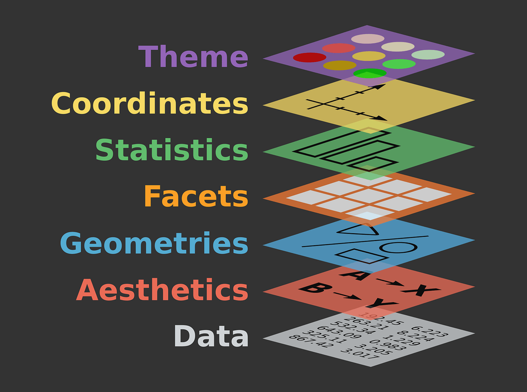

From Saketh Ram Gangam

- `ggplot2` builts a plot by adding multiple layers, each of which has a specific role. At the most basic level, a `ggplot2` consist of:
  - The data set to visualize
  - Aesthetics that map variables to visual properties
  - Geometry to represent the observations
- Common aesthetics include:
  - `x` for the x-axis
  - `y` for the y-axis
  - `fill` for interior color (bars, areas, polygons, etc.)
  - `color` for line or point color
  - `size` for the size of the observation
  - `alpha` for adjusting transparency
  - `shape` for the shape of the observation
- Common geometries include:
  - `geom_point` for scatter plot
  - `geom_bar` for bar plot
  - `geom_line` for line plot
  - `geom_smooth` for smoothing line
  - `geom_histogram` for histogram
  - `geom_density` for density curve
  - `geom_boxplot` for box plot
  - `geom_violin` for violin plot
- Facets divide data into groups and display multiple plots to compare them.
- Statistics provide summaries and transformations.
- Coordinates control the position of data points: Cartesian, fixed-aspect ratio, or polar coordiate.
- Theme controls the appearance of the plot and annotations.
- The [R Graph Gallery](https://r-graph-gallery.com/) provides a collection of graphs made with base R and `ggplot2`.